# Assignment 4

Kai Lukowiak

2018-03-25

Abstract

This paper looks into the predictive ability of certain factors into the likelyhood of a person getting into an accident and also the amount that the accident will cost.

# 1 Data Exploration

## 1.1 The Data Frames

| TARGET_FLAG | TARGET_AMT | KIDSDRIV | AGE | HOMEKIDS | YOJ | INCOME | PARENT1 | HOME_VAL | MSTATUS | SEX | EDUCATION | JOB | TRAVTIME | CAR_USE | BLUEBOOK | TIF | CAR_TYPE | RED_CAR | OLDCLAIM | CLM_FREQ | REVOKED | MVR_PTS | CAR_AGE | URBANICITY |
| --- | --- | --- | --- | --- | --- | --- | --- | --- | --- | --- | --- | --- | --- | --- | --- | --- | --- | --- | --- | --- | --- | --- | --- | --- |
| 0 | 0.000 | 0 | 30 | 2 | 13 | 103881 | No | 287047 | Yes | M | Bachelors | z_Blue Collar | 33 | Commercial | 14890 | 1 | Minivan | no | 0 | 0 | No | 1 | 9 | z_Highly Rural/ Rural |
| 1 | 2044.217 | 0 | 33 | 0 | 9 | 69641 | No | 230290 | z_No | M | Bachelors | z_Blue Collar | 33 | Commercial | 22680 | 1 | Panel Truck | yes | 1712 | 4 | No | 2 | 15 | Highly Urban/ Urban |
| 0 | 0.000 | 0 | 46 | 0 | 12 | 88359 | No | 267679 | Yes | z_F | Masters | Lawyer | 25 | Private | 31980 | 3 | Minivan | no | 0 | 0 | Yes | 0 | 1 | Highly Urban/ Urban |
| 0 | 0.000 | 0 | 27 | 3 | 7 | 131567 | Yes | 0 | z_No | z_F | Bachelors | Professional | 32 | Private | 8790 | 1 | Minivan | no | 0 | 0 | No | 3 | 1 | Highly Urban/ Urban |
| 0 | 0.000 | 0 | 51 | 0 | 13 | 85345 | No | NA | Yes | M | Masters | NA | 37 | Commercial | 34270 | 4 | Panel Truck | no | 8481 | 3 | No | 5 | 15 | Highly Urban/ Urban |
| 0 | 0.000 | 0 | 35 | 1 | 10 | 16039 | No | 124191 | Yes | z_F | z_High School | Clerical | 5 | Private | 4010 | 4 | z_SUV | no | 38690 | 2 | No | 3 | 10 | Highly Urban/ Urban |

```
## Observations: 6,121
## Variables: 25
## $ TARGET_FLAG <int> 0, 0, 0, 0, 0, 1, 0, 1, 1, 0, 1, 0, 0, 1, 1, 0, 0,...
## $ TARGET_AMT  <dbl> 0.000, 0.000, 0.000, 0.000, 0.000, 2946.000, 0.000...
## $ KIDSDRIV    <int> 0, 0, 0, 0, 0, 0, 0, 1, 0, 0, 0, 0, 0, 0, 0, 0, 0,...
## $ AGE         <int> 60, 43, 35, 51, 50, 34, 54, 37, 34, 50, 53, 43, 55...
## $ HOMEKIDS    <int> 0, 0, 1, 0, 0, 1, 0, 2, 0, 0, 0, 0, 0, 0, 0, 3, 3,...
## $ YOJ         <int> 11, 11, 10, 14, NA, 12, NA, NA, 10, 7, 14, 5, 11, ...
## $ INCOME      <dbl> 67349, 91449, 16039, NA, 114986, 125301, 18755, 10...
## $ PARENT1     <fct> No, No, No, No, No, Yes, No, No, No, No, No, No, N...
## $ HOME_VAL    <dbl> 0, 257252, 124191, 306251, 243925, 0, NA, 333680, ...
## $ MSTATUS     <fct> z_No, z_No, Yes, Yes, Yes, z_No, Yes, Yes, z_No, z...
## $ SEX         <fct> M, M, z_F, M, z_F, z_F, z_F, M, z_F, M, z_F, z_F, ...
## $ EDUCATION   <fct> PhD, z_High School, z_High School, <High School, P...
## $ JOB         <fct> Professional, z_Blue Collar, Clerical, z_Blue Coll...
## $ TRAVTIME    <int> 14, 22, 5, 32, 36, 46, 33, 44, 34, 48, 15, 36, 25,...
## $ CAR_USE     <fct> Private, Commercial, Private, Private, Private, Co...
## $ BLUEBOOK    <dbl> 14230, 14940, 4010, 15440, 18000, 17430, 8780, 169...
## $ TIF         <int> 11, 1, 4, 7, 1, 1, 1, 1, 1, 7, 1, 7, 7, 6, 1, 6, 7...
## $ CAR_TYPE    <fct> Minivan, Minivan, z_SUV, Minivan, z_SUV, Sports Ca...
## $ RED_CAR     <fct> yes, yes, no, yes, no, no, no, yes, no, no, no, no...
## $ OLDCLAIM    <dbl> 4461, 0, 38690, 0, 19217, 0, 0, 2374, 0, 0, 0, 0, ...
## $ CLM_FREQ    <int> 2, 0, 2, 0, 2, 0, 0, 1, 0, 0, 0, 0, 2, 0, 0, 0, 0,...
## $ REVOKED     <fct> No, No, No, No, Yes, No, No, Yes, No, No, No, No, ...
## $ MVR_PTS     <int> 3, 0, 3, 0, 3, 0, 0, 10, 0, 1, 0, 0, 3, 3, 3, 0, 0...
## $ CAR_AGE     <int> 18, 1, 10, 6, 17, 7, 1, 7, 1, 17, 11, 1, 9, 10, 5,...
## $ URBANICITY  <fct> Highly Urban/ Urban, Highly Urban/ Urban, Highly U...
```

Sample of Values for the Test Set

| KIDSDRIV | AGE | HOMEKIDS | YOJ | INCOME | PARENT1 | HOME_VAL | MSTATUS |
| --- | --- | --- | --- | --- | --- | --- | --- |
| 0 | 47 | 0 | 12 | 36150 | No | 174964 | Yes |
| 0 | 57 | 0 | 10 | 130831 | No | 365792 | Yes |
| 0 | 50 | 0 | 14 | 15989 | No | 117038 | Yes |
| 0 | 47 | 0 | 14 | 2825 | No | 91520 | Yes |
| 0 | 58 | 0 | 12 | 73283 | No | 251025 | Yes |
| 0 | 39 | 3 | 14 | 51524 | Yes | 0 | z_No |

The evaluation set is a similar data frame but excludes the target variable. As such it cannot be used for cross validation.

[output not shown]

## 1.2 Summary Statistics

Summary Statistics

|  | TARGET_FLAG | TARGET_AMT | KIDSDRIV | AGE | HOMEKIDS | YOJ |
| --- | --- | --- | --- | --- | --- | --- |
|  | Min. :0.0000 | Min. : 0 | Min. :0.0000 | Min. :16.00 | Min. :0.0000 | Min. : 0.00 |
|  | 1st Qu.:0.0000 | 1st Qu.: 0 | 1st Qu.:0.0000 | 1st Qu.:39.00 | 1st Qu.:0.0000 | 1st Qu.: 9.00 |
|  | Median :0.0000 | Median : 0 | Median :0.0000 | Median :45.00 | Median :0.0000 | Median :11.00 |
|  | Mean :0.2638 | Mean : 1514 | Mean :0.1704 | Mean :44.68 | Mean :0.7298 | Mean :10.53 |
|  | 3rd Qu.:1.0000 | 3rd Qu.: 1029 | 3rd Qu.:0.0000 | 3rd Qu.:51.00 | 3rd Qu.:1.0000 | 3rd Qu.:13.00 |
|  | Max. :1.0000 | Max. :107586 | Max. :4.0000 | Max. :73.00 | Max. :5.0000 | Max. :19.00 |
|  | NA | NA | NA | NA’s :3 | NA | NA’s :347 |

Summary Statistics

|  | INCOME | PARENT1 | HOME_VAL | MSTATUS | SEX | EDUCATION | JOB |
| --- | --- | --- | --- | --- | --- | --- | --- |
|  | Min. : 0 | No :5289 | Min. : 0 | Yes :3659 | M :2827 | <High School : 933 | z_Blue Collar:1375 |
|  | 1st Qu.: 27658 | Yes: 832 | 1st Qu.: 0 | z_No:2462 | z_F:3294 | Bachelors :1693 | Clerical : 961 |
|  | Median : 53904 | NA | Median :159417 | NA | NA | Masters :1240 | Professional : 834 |
|  | Mean : 61890 | NA | Mean :154164 | NA | NA | PhD : 541 | Manager : 738 |
|  | 3rd Qu.: 86464 | NA | 3rd Qu.:238931 | NA | NA | z_High School:1714 | Lawyer : 615 |
|  | Max. :367030 | NA | Max. :885282 | NA | NA | NA | (Other) :1191 |
|  | NA’s :343 | NA | NA’s :344 | NA | NA | NA | NA’s : 407 |

These tables give an overview of the variables, suggesting there may be some issues with distributions but we will need to look further before making any decisions on transforming the variables.

## 1.3 Descriptive Statistics

Descriptive Statistics

|  | vars | n | mean | sd | median |
| --- | --- | --- | --- | --- | --- |
| TARGET_FLAG | 1 | 6121 | 2.638458e-01 | 4.407527e-01 | 0.0 |
| TARGET_AMT | 2 | 6121 | 1.514009e+03 | 4.776983e+03 | 0.0 |
| KIDSDRIV | 3 | 6121 | 1.703970e-01 | 5.102345e-01 | 0.0 |
| AGE | 4 | 6118 | 4.467980e+01 | 8.647718e+00 | 45.0 |
| HOMEKIDS | 5 | 6121 | 7.297827e-01 | 1.122196e+00 | 0.0 |
| YOJ | 6 | 5774 | 1.053152e+01 | 4.084161e+00 | 11.0 |
| INCOME | 7 | 5778 | 6.188946e+04 | 4.785552e+04 | 53903.5 |
| PARENT1* | 8 | 6121 | 1.135925e+00 | 3.427374e-01 | 1.0 |
| HOME_VAL | 9 | 5777 | 1.541642e+05 | 1.303360e+05 | 159417.0 |
| MSTATUS* | 10 | 6121 | 1.402222e+00 | 4.903863e-01 | 1.0 |
| SEX* | 11 | 6121 | 1.538147e+00 | 4.985834e-01 | 2.0 |
| EDUCATION* | 12 | 6121 | 3.066982e+00 | 1.445894e+00 | 3.0 |
| JOB* | 13 | 5714 | 5.008050e+00 | 2.468908e+00 | 5.0 |
| TRAVTIME | 14 | 6121 | 3.347100e+01 | 1.593407e+01 | 33.0 |
| CAR_USE* | 15 | 6121 | 1.627022e+00 | 4.836359e-01 | 2.0 |
| BLUEBOOK | 16 | 6121 | 1.567134e+04 | 8.455444e+03 | 14380.0 |
| TIF | 17 | 6121 | 5.349616e+00 | 4.106822e+00 | 4.0 |
| CAR_TYPE* | 18 | 6121 | 3.521157e+00 | 1.960455e+00 | 3.0 |
| RED_CAR* | 19 | 6121 | 1.290802e+00 | 4.541695e-01 | 1.0 |
| OLDCLAIM | 20 | 6121 | 4.070660e+03 | 8.867756e+03 | 0.0 |
| CLM_FREQ | 21 | 6121 | 7.952949e-01 | 1.152753e+00 | 0.0 |
| REVOKED* | 22 | 6121 | 1.121549e+00 | 3.267906e-01 | 1.0 |
| MVR_PTS | 23 | 6121 | 1.719164e+00 | 2.150401e+00 | 1.0 |
| CAR_AGE | 24 | 5735 | 8.334612e+00 | 5.747126e+00 | 8.0 |
| URBANICITY* | 25 | 6121 | 1.207156e+00 | 4.053012e-01 | 1.0 |

Descriptive Statistics

|  | trimmed | mad | min | max |
| --- | --- | --- | --- | --- |
| TARGET_FLAG | 2.048193e-01 | 0.0000 | 0 | 1.0 |
| TARGET_AMT | 5.889851e+02 | 0.0000 | 0 | 107586.1 |
| KIDSDRIV | 2.470900e-02 | 0.0000 | 0 | 4.0 |
| AGE | 4.473284e+01 | 8.8956 | 16 | 73.0 |
| HOMEKIDS | 5.064325e-01 | 0.0000 | 0 | 5.0 |
| YOJ | 1.110736e+01 | 2.9652 | 0 | 19.0 |
| INCOME | 5.676326e+04 | 42610.6653 | 0 | 367030.0 |
| PARENT1* | 1.044925e+00 | 0.0000 | 1 | 2.0 |
| HOME_VAL | 1.428207e+05 | 152887.1946 | 0 | 885282.0 |
| MSTATUS* | 1.377782e+00 | 0.0000 | 1 | 2.0 |
| SEX* | 1.547682e+00 | 0.0000 | 1 | 2.0 |
| EDUCATION* | 3.083725e+00 | 1.4826 | 1 | 5.0 |
| JOB* | 5.134952e+00 | 2.9652 | 1 | 8.0 |
| TRAVTIME | 3.301062e+01 | 16.3086 | 5 | 142.0 |
| CAR_USE* | 1.658771e+00 | 0.0000 | 1 | 2.0 |
| BLUEBOOK | 1.498274e+04 | 8510.1240 | 1500 | 69740.0 |
| TIF | 4.854605e+00 | 4.4478 | 1 | 25.0 |
| CAR_TYPE* | 3.526445e+00 | 2.9652 | 1 | 6.0 |
| RED_CAR* | 1.238513e+00 | 0.0000 | 1 | 2.0 |
| OLDCLAIM | 1.727992e+03 | 0.0000 | 0 | 57037.0 |
| CLM_FREQ | 5.860731e-01 | 0.0000 | 0 | 5.0 |
| REVOKED* | 1.026955e+00 | 0.0000 | 1 | 2.0 |
| MVR_PTS | 1.341842e+00 | 1.4826 | 0 | 13.0 |
| CAR_AGE | 7.954892e+00 | 7.4130 | 0 | 28.0 |
| URBANICITY* | 1.133960e+00 | 0.0000 | 1 | 2.0 |

Descriptive Statistics

|  | range | skew | kurtosis | se |
| --- | --- | --- | --- | --- |
| TARGET_FLAG | 1.0 | 1.0714201 | -0.8521981 | 0.0056336 |
| TARGET_AMT | 107586.1 | 8.7901683 | 115.2132560 | 61.0579864 |
| KIDSDRIV | 4.0 | 3.3505408 | 11.7603038 | 0.0065217 |
| AGE | 57.0 | -0.0564481 | -0.0854251 | 0.1105597 |
| HOMEKIDS | 5.0 | 1.3343569 | 0.6505442 | 0.0143436 |
| YOJ | 19.0 | -1.2180676 | 1.1808636 | 0.0537483 |
| INCOME | 367030.0 | 1.2145580 | 2.2994723 | 629.5688594 |
| PARENT1* | 1.0 | 2.1241626 | 2.5124772 | 0.0043808 |
| HOME_VAL | 885282.0 | 0.5294461 | 0.0815993 | 1714.7992717 |
| MSTATUS* | 1.0 | 0.3987149 | -1.8413272 | 0.0062680 |
| SEX* | 1.0 | -0.1529980 | -1.9769145 | 0.0063727 |
| EDUCATION* | 4.0 | 0.1363664 | -1.3715543 | 0.0184810 |
| JOB* | 7.0 | -0.3418602 | -1.1629758 | 0.0326614 |
| TRAVTIME | 137.0 | 0.4428075 | 0.7156313 | 0.2036646 |
| CAR_USE* | 1.0 | -0.5251925 | -1.7244545 | 0.0061817 |
| BLUEBOOK | 68240.0 | 0.8097543 | 0.8315495 | 108.0749994 |
| TIF | 24.0 | 0.8608451 | 0.3166601 | 0.0524922 |
| CAR_TYPE* | 5.0 | 0.0052126 | -1.5099694 | 0.0250580 |
| RED_CAR* | 1.0 | 0.9210819 | -1.1517962 | 0.0058051 |
| OLDCLAIM | 57037.0 | 3.1274684 | 9.9061482 | 113.3450445 |
| CLM_FREQ | 5.0 | 1.2115436 | 0.3061895 | 0.0147342 |
| REVOKED* | 1.0 | 2.3157911 | 3.3634379 | 0.0041769 |
| MVR_PTS | 13.0 | 1.3131263 | 1.2250866 | 0.0274858 |
| CAR_AGE | 28.0 | 0.2984052 | -0.7372102 | 0.0758899 |
| URBANICITY* | 1.0 | 1.4448340 | 0.0875597 | 0.0051804 |

The count of NA values for each variable is given below.

Count of NA Values

| x |
| --- |
| 0 |

| x |
| --- |
| 0 |

| x |
| --- |
| 0 |

| x |
| --- |
| 3 |

| x |
| --- |
| 0 |

| x |
| --- |
| 347 |

| x |
| --- |
| 343 |

| x |
| --- |
| 0 |

Count of NA Values

| x |
| --- |
| 344 |

| x |
| --- |
| 0 |

| x |
| --- |
| 0 |

| x |
| --- |
| 0 |

| x |
| --- |
| 407 |

| x |
| --- |
| 0 |

| x |
| --- |
| 0 |

| x |
| --- |
| 0 |

| x |
| --- |
| 0 |

Count of NA Values

| x |
| --- |
| 0 |

| x |
| --- |
| 0 |

| x |
| --- |
| 0 |

| x |
| --- |
| 0 |

| x |
| --- |
| 0 |

| x |
| --- |
| 0 |

| x |
| --- |
| 386 |

| x |
| --- |
| 0 |

There are quite a few missing values accross several variables. However, compared to the size of the training set, around 6000, these numbers could be dropped if there is no correlation between the missing values and the response variables.

The correlation between missing values and the ‘Claim Filed’ response is -3.151689910^{-4} and 0.0086636 for the claim amount. Since these are very close to zero we are not worried about them effecting the regressions. As such, we will drop them.

## 1.4 Graphical EDA

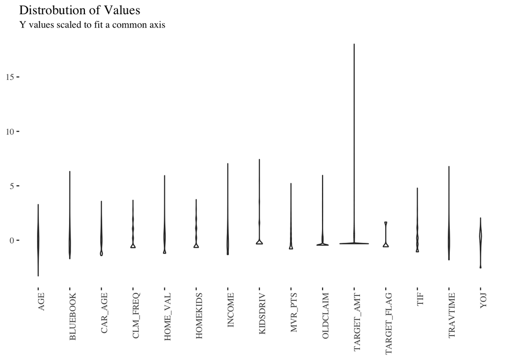

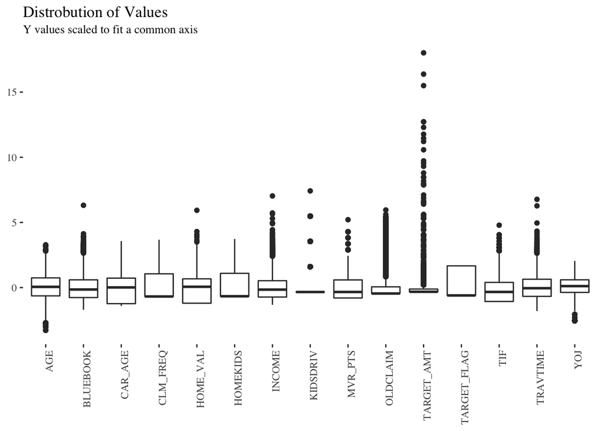

From these two graphs we can see that many of distributions are skewed in one direction or another. It is also interesting to see that the target variable is below zero. This means that the median and mean values are different.

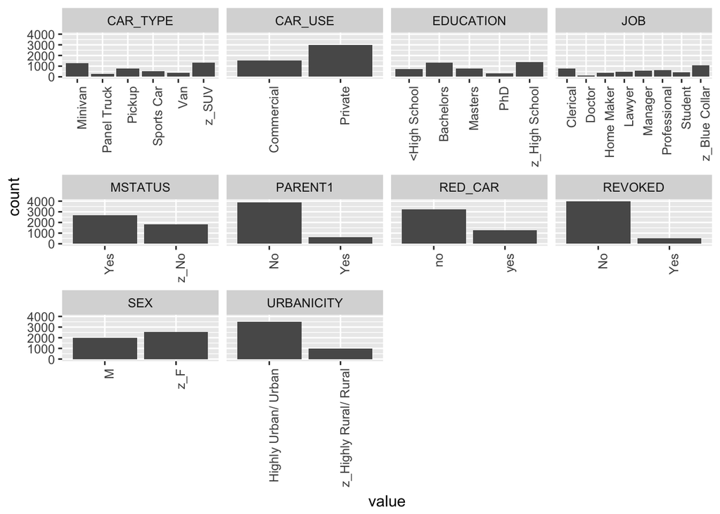

The factor variables some uneven counts as well but nothing that is highly out of the ordinary.

# 2 Data Preperation

## 2.1 Transformed Skewed Variables

I will log transform `TARGET_AMT` in one of the models that build to account for the wide range. During this transformation it is important to add 1 to each variable because there are many zero values that would throw and error.

I also transformed `TARGET_AMT` with the power of -0.4 based off of a Box-Cox analysis. Given the nature of other variables it does not seem necessary to transform others.

# 3 Build Models

Model selection will be based off of automated selection techniques as well as specific transformations.

## 3.1 Ordinary Least Squares

### 3.1.1 Baisic Regression

Here I regressed all variables without transformation.

Call: lm(formula = TARGET_AMT ~ ., data = dfCont)

Residuals: Min 1Q Median 3Q Max -5602 -1702 -733 419 82515

Coefficients: Estimate Std. Error t value Pr(>|t|)  
(Intercept) 2.206e+03 6.267e+02 3.520 0.000436 KIDSDRIV 2.624e+02 1.487e+02 1.765 0.077705 .  
AGE -5.843e+00 9.387e+00 -0.622 0.533648  
HOMEKIDS -3.457e+01 8.506e+01 -0.406 0.684471  
YOJ -8.626e+00 1.944e+01 -0.444 0.657279  
INCOME -2.588e-03 2.719e-03 -0.952 0.341152  
PARENT1Yes 6.711e+02 2.643e+02 2.539 0.011153  
HOME_VAL -1.373e-03 8.504e-04 -1.615 0.106471  
MSTATUSz_No 4.870e+02 2.001e+02 2.434 0.014982 *  
SEXz_F -3.404e+02 2.408e+02 -1.414 0.157515  
EDUCATIONBachelors -3.255e+02 2.662e+02 -1.222 0.221603  
EDUCATIONMasters -3.557e+02 4.018e+02 -0.885 0.376129  
EDUCATIONPhD 5.905e+02 4.993e+02 1.183 0.236960  
EDUCATIONz_High School -1.534e+02 2.200e+02 -0.697 0.485834  
JOBDoctor -1.365e+03 5.902e+02 -2.313 0.020762 *  
JOBHome Maker 1.498e+01 3.263e+02 0.046 0.963375  
JOBLawyer 1.771e+02 4.001e+02 0.443 0.658116  
JOBManager -9.372e+02 3.075e+02 -3.048 0.002320 JOBProfessional 2.831e+02 2.825e+02 1.002 0.316268  
JOBStudent -2.023e+02 3.145e+02 -0.643 0.520122  
JOBz_Blue Collar 8.733e+01 2.464e+02 0.354 0.723062  
TRAVTIME 1.666e+01 4.277e+00 3.895 9.98e-05 *CAR_USEPrivate -8.516e+02 2.169e+02 -3.926 8.76e-05* BLUEBOOK 1.124e-02 1.139e-02 0.987 0.323848  
TIF -4.546e+01 1.639e+01 -2.773 0.005570 ** CAR_TYPEPanel Truck 3.648e+02 3.928e+02 0.929 0.353128  
CAR_TYPEPickup 4.390e+02 2.222e+02 1.975 0.048285 *  
CAR_TYPESports Car 1.304e+03 2.773e+02 4.704 2.63e-06 CAR_TYPEVan 5.659e+02 2.912e+02 1.943 0.052050 .  
CAR_TYPEz_SUV 7.651e+02 2.299e+02 3.328 0.000881 RED_CARyes -1.374e+02 2.034e+02 -0.676 0.499234  
OLDCLAIM -7.776e-03 9.851e-03 -0.789 0.429963  
CLM_FREQ 5.019e+01 7.386e+01 0.680 0.496839  
REVOKEDYes 3.721e+02 2.356e+02 1.580 0.114251  
MVR_PTS 1.654e+02 3.434e+01 4.817 1.51e-06 CAR_AGE -2.414e+01 1.720e+01 -1.404 0.160504  
URBANICITYz_Highly Rural/ Rural -1.918e+03 1.814e+02 -10.573 < 2e-16 — Signif. codes: 0 ‘**’ 0.001 ’**’ 0.01 ’’ 0.05 ‘.’ 0.1 ‘’ 1

Residual standard error: 4494 on 4468 degrees of freedom Multiple R-squared: 0.07951, Adjusted R-squared: 0.07209 F-statistic: 10.72 on 36 and 4468 DF, p-value: < 2.2e-16

This is a pretty poor $R^2$. While there are some significant variables, the overall performance is poor.

### 3.1.2 Log Transformed

Next we look at the regression with a log transformed `TARGET_AMT` variable.

Call: lm(formula = log(TARGET_AMT + 1) ~ ., data = dfCont)

Residuals: Min 1Q Median 3Q Max -8.173 -2.340 -0.850 2.146 11.054

Coefficients: Estimate Std. Error t value Pr(>|t|)  
(Intercept) 3.640e+00 4.466e-01 8.150 4.66e-16 *KIDSDRIV 3.949e-01 1.060e-01 3.727 0.000197* AGE -6.131e-03 6.689e-03 -0.916 0.359457  
HOMEKIDS -2.705e-02 6.061e-02 -0.446 0.655468  
YOJ -1.264e-02 1.385e-02 -0.912 0.361683  
INCOME -3.189e-06 1.937e-06 -1.646 0.099790 .  
PARENT1Yes 8.902e-01 1.884e-01 4.726 2.36e-06 *HOME_VAL -1.442e-06 6.060e-07 -2.379 0.017379*  
MSTATUSz_No 4.756e-01 1.426e-01 3.335 0.000860 SEXz_F -1.547e-01 1.716e-01 -0.902 0.367280  
EDUCATIONBachelors -5.226e-01 1.897e-01 -2.755 0.005901 EDUCATIONMasters -4.859e-01 2.864e-01 -1.697 0.089781 .  
EDUCATIONPhD 1.498e-01 3.558e-01 0.421 0.673785  
EDUCATIONz_High School 4.030e-02 1.568e-01 0.257 0.797156  
JOBDoctor -1.388e+00 4.206e-01 -3.299 0.000978 JOBHome Maker -3.566e-01 2.325e-01 -1.534 0.125162  
JOBLawyer -2.596e-01 2.851e-01 -0.910 0.362667  
JOBManager -1.395e+00 2.191e-01 -6.368 2.11e-10 *JOBProfessional -4.193e-01 2.013e-01 -2.083 0.037331*  
JOBStudent -4.121e-01 2.241e-01 -1.839 0.065963 .  
JOBz_Blue Collar -3.573e-01 1.756e-01 -2.035 0.041932 *  
TRAVTIME 2.163e-02 3.048e-03 7.095 1.50e-12 *CAR_USEPrivate -1.199e+00 1.546e-01 -7.754 1.10e-14* BLUEBOOK -2.055e-05 8.115e-06 -2.532 0.011368 *  
TIF -6.686e-02 1.168e-02 -5.724 1.11e-08 CAR_TYPEPanel Truck 5.446e-01 2.800e-01 1.945 0.051794 .  
CAR_TYPEPickup 6.586e-01 1.584e-01 4.159 3.26e-05 **CAR_TYPESports Car 1.332e+00 1.976e-01 6.740 1.78e-11** *CAR_TYPEVan 5.699e-01 2.075e-01 2.746 0.006057 **CAR_TYPEz_SUV 8.588e-01 1.638e-01 5.242 1.66e-07*** RED_CARyes -2.352e-01 1.449e-01 -1.623 0.104640  
OLDCLAIM -1.883e-05 7.020e-06 -2.682 0.007347 ** CLM_FREQ 2.477e-01 5.263e-02 4.706 2.60e-06 *REVOKEDYes 1.058e+00 1.679e-01 6.300 3.27e-10* MVR_PTS 1.949e-01 2.447e-02 7.965 2.07e-15 CAR_AGE -8.615e-03 1.226e-02 -0.703 0.482150  
URBANICITYz_Highly Rural/ Rural -2.571e+00 1.293e-01 -19.894 < 2e-16 — Signif. codes: 0 ‘**’ 0.001 ’**’ 0.01 ’’ 0.05 ‘.’ 0.1 ‘’ 1

Residual standard error: 3.203 on 4468 degrees of freedom Multiple R-squared: 0.2429, Adjusted R-squared: 0.2368 F-statistic: 39.81 on 36 and 4468 DF, p-value: < 2.2e-16

This is an improvement. It makes sense that we would need to transform the response variable given it’s skewed nature.

## 3.2 BoxCox

bcPower Transformation to Normality Est Power Rounded Pwr Wald Lwr bnd Wald Upr Bnd Y1 -0.3997 -0.4 -0.4151 -0.3842

Likelihood ratio tests about transformation parameters LRT df pval LR test, lambda = (0) 3334.454 1 0 LR test, lambda = (1) 48980.134 1 0

Call: lm(formula = I((TARGET_AMT + 1)^(-0.4)) ~ ., data = dfCont)

Residuals: Min 1Q Median 3Q Max -1.22372 -0.26618 0.09885 0.27222 0.94841

Coefficients: Estimate Std. Error t value Pr(>|t|)  
(Intercept) 5.718e-01 5.158e-02 11.087 < 2e-16 *KIDSDRIV -4.597e-02 1.224e-02 -3.756 0.000175* AGE 7.686e-04 7.725e-04 0.995 0.319821  
HOMEKIDS 3.092e-03 7.000e-03 0.442 0.658701  
YOJ 1.362e-03 1.600e-03 0.851 0.394739  
INCOME 3.641e-07 2.238e-07 1.627 0.103780  
PARENT1Yes -1.008e-01 2.175e-02 -4.633 3.71e-06 *HOME_VAL 1.613e-07 6.999e-08 2.304 0.021244*  
MSTATUSz_No -5.537e-02 1.647e-02 -3.362 0.000781 SEXz_F 1.657e-02 1.982e-02 0.836 0.403263  
EDUCATIONBachelors 5.935e-02 2.191e-02 2.709 0.006782 EDUCATIONMasters 5.585e-02 3.307e-02 1.689 0.091322 .  
EDUCATIONPhD -1.270e-02 4.109e-02 -0.309 0.757357  
EDUCATIONz_High School -4.987e-03 1.811e-02 -0.275 0.783029  
JOBDoctor 1.581e-01 4.858e-02 3.255 0.001140 JOBHome Maker 4.226e-02 2.686e-02 1.573 0.115690  
JOBLawyer 3.300e-02 3.293e-02 1.002 0.316351  
JOBManager 1.629e-01 2.531e-02 6.438 1.34e-10 JOBProfessional 5.427e-02 2.325e-02 2.334 0.019625 *  
JOBStudent 4.755e-02 2.588e-02 1.837 0.066220 .  
JOBz_Blue Collar 4.227e-02 2.028e-02 2.084 0.037178 *  
TRAVTIME -2.493e-03 3.520e-04 -7.080 1.66e-12 *CAR_USEPrivate 1.393e-01 1.785e-02 7.801 7.62e-15* **BLUEBOOK 2.603e-06 9.372e-07 2.778 0.005501** TIF 7.735e-03 1.349e-03 5.734 1.05e-08 CAR_TYPEPanel Truck -6.329e-02 3.233e-02 -1.957 0.050359 .  
CAR_TYPEPickup -7.585e-02 1.829e-02 -4.147 3.43e-05 CAR_TYPESports Car -1.518e-01 2.282e-02 -6.650 3.29e-11 **CAR_TYPEVan -6.372e-02 2.397e-02 -2.659 0.007873** CAR_TYPEz_SUV -9.798e-02 1.892e-02 -5.179 2.33e-07 RED_CARyes 2.835e-02 1.674e-02 1.694 0.090340 .  
OLDCLAIM 2.323e-06 8.108e-07 2.865 0.004186 CLM_FREQ -3.064e-02 6.079e-03 -5.041 4.82e-07 *REVOKEDYes -1.255e-01 1.939e-02 -6.471 1.08e-10* MVR_PTS -2.202e-02 2.826e-03 -7.791 8.19e-15 CAR_AGE 9.464e-04 1.415e-03 0.669 0.503748  
URBANICITYz_Highly Rural/ Rural 2.970e-01 1.493e-02 19.898 < 2e-16 — Signif. codes: 0 ‘**’ 0.001 ’**’ 0.01 ’’ 0.05 ‘.’ 0.1 ‘’ 1

Residual standard error: 0.3699 on 4468 degrees of freedom Multiple R-squared: 0.2444, Adjusted R-squared: 0.2383 F-statistic: 40.13 on 36 and 4468 DF, p-value: < 2.2e-16

## 3.3 Regular logostic

Call: glm(formula = TARGET_FLAG ~ ., data = dfLog)

Deviance Residuals: Min 1Q Median 3Q Max  
-0.9859 -0.2831 -0.1032 0.2783 1.2625

Coefficients: Estimate Std. Error t value Pr(>|t|)  
(Intercept) 4.462e-01 5.365e-02 8.316 < 2e-16 *KIDSDRIV 4.778e-02 1.273e-02 3.753 0.000177* AGE -8.077e-04 8.036e-04 -1.005 0.314936  
HOMEKIDS -3.191e-03 7.282e-03 -0.438 0.661319  
YOJ -1.397e-03 1.665e-03 -0.839 0.401432  
INCOME -3.775e-07 2.328e-07 -1.622 0.104895  
PARENT1Yes 1.043e-01 2.263e-02 4.607 4.19e-06 *HOME_VAL -1.665e-07 7.281e-08 -2.286 0.022276*  
MSTATUSz_No 5.775e-02 1.713e-02 3.370 0.000757 SEXz_F -1.718e-02 2.062e-02 -0.833 0.404608  
EDUCATIONBachelors -6.133e-02 2.279e-02 -2.690 0.007162 EDUCATIONMasters -5.796e-02 3.440e-02 -1.685 0.092145 .  
EDUCATIONPhD 1.286e-02 4.274e-02 0.301 0.763509  
EDUCATIONz_High School 5.205e-03 1.884e-02 0.276 0.782319  
JOBDoctor -1.644e-01 5.053e-02 -3.253 0.001149 JOBHome Maker -4.396e-02 2.794e-02 -1.574 0.115658  
JOBLawyer -3.464e-02 3.426e-02 -1.011 0.311951  
JOBManager -1.696e-01 2.633e-02 -6.444 1.29e-10 JOBProfessional -5.725e-02 2.419e-02 -2.367 0.017962 *  
JOBStudent -4.933e-02 2.692e-02 -1.832 0.066990 .  
JOBz_Blue Collar -4.370e-02 2.110e-02 -2.071 0.038385 *  
TRAVTIME 2.589e-03 3.662e-04 7.071 1.78e-12 *CAR_USEPrivate -1.449e-01 1.857e-02 -7.802 7.52e-15* **BLUEBOOK -2.743e-06 9.749e-07 -2.814 0.004916** TIF -8.044e-03 1.403e-03 -5.732 1.06e-08 CAR_TYPEPanel Truck 6.574e-02 3.363e-02 1.955 0.050694 .  
CAR_TYPEPickup 7.887e-02 1.903e-02 4.146 3.45e-05 CAR_TYPESports Car 1.575e-01 2.374e-02 6.632 3.71e-11 **CAR_TYPEVan 6.581e-02 2.493e-02 2.640 0.008331** CAR_TYPEz_SUV 1.015e-01 1.968e-02 5.159 2.59e-07 RED_CARyes -2.978e-02 1.741e-02 -1.710 0.087280 .  
OLDCLAIM -2.447e-06 8.434e-07 -2.901 0.003740 CLM_FREQ 3.222e-02 6.324e-03 5.096 3.62e-07 *REVOKEDYes 1.308e-01 2.017e-02 6.484 9.92e-11* MVR_PTS 2.279e-02 2.940e-03 7.752 1.11e-14 CAR_AGE -9.862e-04 1.472e-03 -0.670 0.503048  
URBANICITYz_Highly Rural/ Rural -3.087e-01 1.553e-02 -19.879 < 2e-16 — Signif. codes: 0 ‘**’ 0.001 ’**’ 0.01 ’’ 0.05 ‘.’ 0.1 ‘’ 1

(Dispersion parameter for gaussian family taken to be 0.1480396)

Null deviance: 875.19 on 4504 degrees of freedom Residual deviance: 661.44 on 4468 degrees of freedom AIC: 4217.7

Number of Fisher Scoring iterations: 2

## 3.4 LASSO Logistic

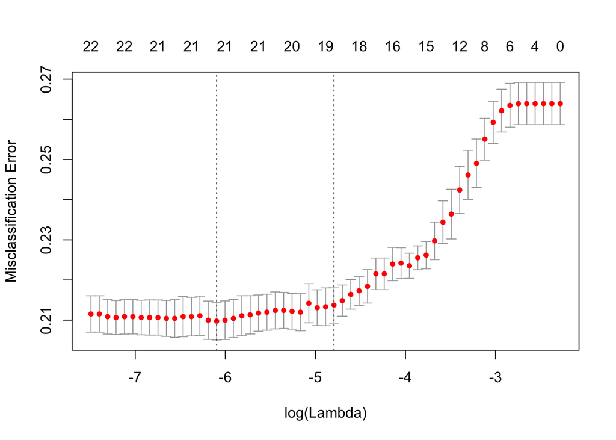

```
## 24 x 1 sparse Matrix of class "dgCMatrix"
##                         1
## (Intercept)  9.311645e-01
## KIDSDRIV     2.104515e-01
## AGE         -3.066729e-03
## HOMEKIDS     .
## YOJ          .
## INCOME      -5.091546e-06
## PARENT1      5.400654e-01
## HOME_VAL    -1.319478e-06
## MSTATUS      2.495976e-01
## SEX          .
## EDUCATION    1.950305e-02
## JOB         -3.135790e-04
## TRAVTIME     1.298654e-02
## CAR_USE     -8.073200e-01
## BLUEBOOK    -1.739624e-05
## TIF         -3.631229e-02
## CAR_TYPE     9.955364e-02
## RED_CAR     -3.785589e-02
## OLDCLAIM     .
## CLM_FREQ     1.374393e-01
## REVOKED      4.762156e-01
## MVR_PTS      1.130536e-01
## CAR_AGE     -1.716225e-02
## URBANICITY  -1.888708e+00
```

### 3.4.1 Theoretical Model

# 4 Chose a Model

Here we chose the best of each class of model.

## 4.1 OLS Models

### 4.1.1 Regular OLS

```
##      rstudent unadjusted p-value Bonferonni p
## 2988 19.17386         8.3009e-79   3.7395e-75
## 3916 17.71827         6.0975e-68   2.7469e-64
## 1393 16.20840         1.8631e-57   8.3935e-54
## 309  13.01407         4.9631e-38   2.2359e-34
## 2422 12.82457         5.3304e-37   2.4013e-33
## 3223 12.77978         9.2987e-37   4.1891e-33
## 2848 12.43057         6.6975e-35   3.0172e-31
## 586  11.88084         4.5067e-32   2.0303e-28
## 3419 11.54189         2.1799e-30   9.8206e-27
## 246  10.19349         3.8883e-24   1.7517e-20
```

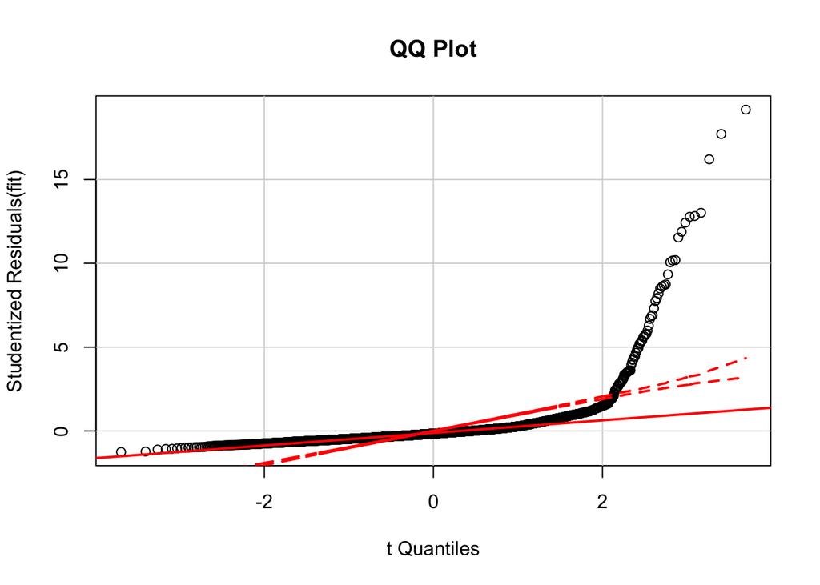

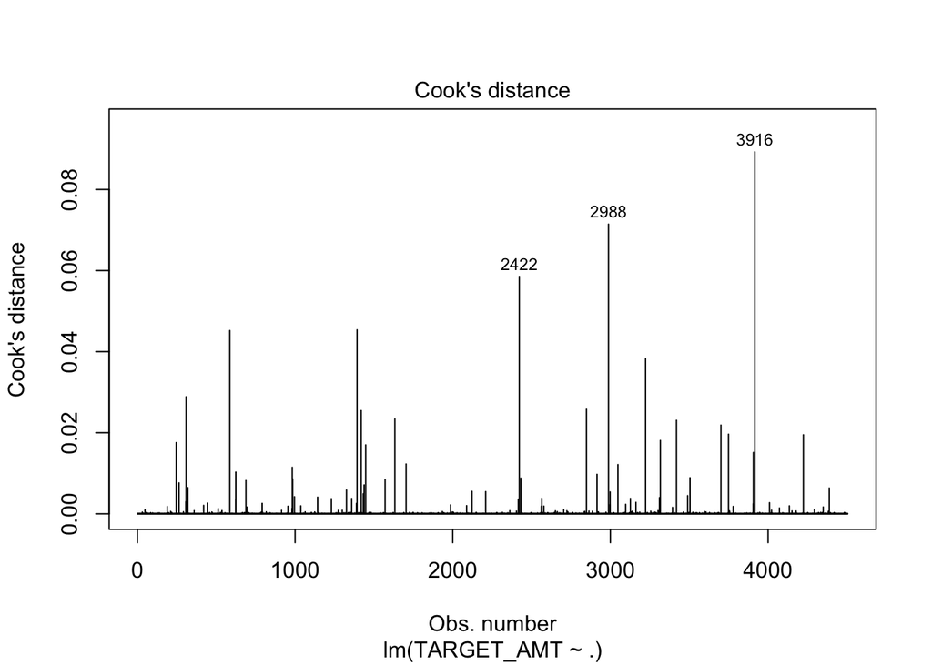

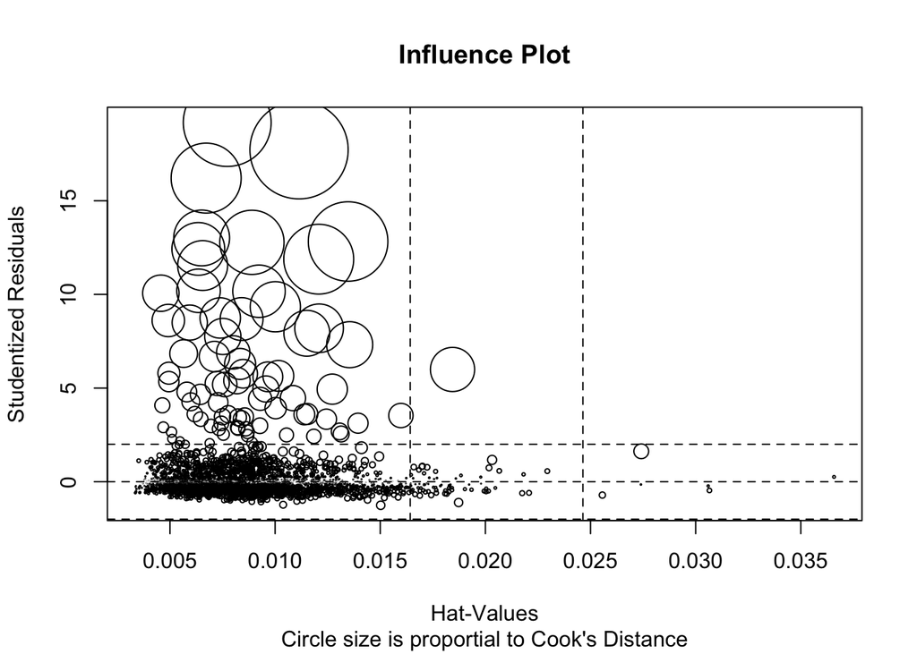

```
## Non-constant Variance Score Test
## Variance formula: ~ fitted.values
## Chisquare = 1937.732    Df = 1     p = 0
```

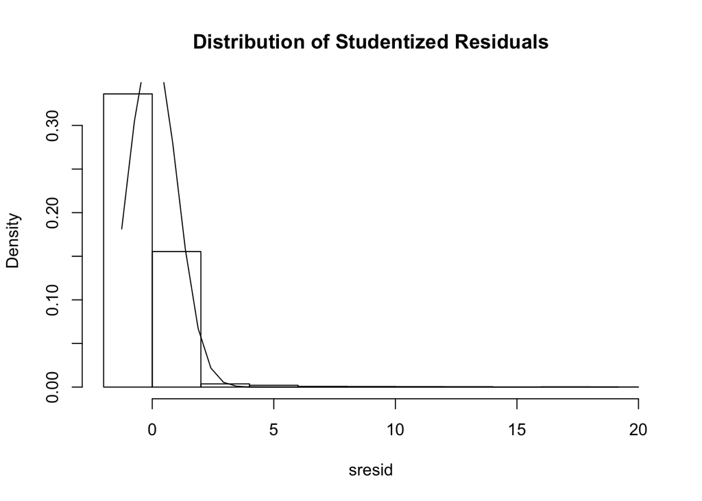

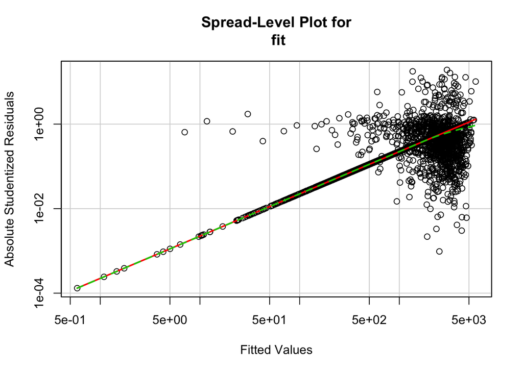

```
##  lag Autocorrelation D-W Statistic p-value
##    1    -0.003806213      2.007557   0.892
##  Alternative hypothesis: rho != 0
```

We can see from the QQ Plot that we have some serious troubles with this model.

```
##
## No Studentized residuals with Bonferonni p < 0.05
## Largest |rstudent|:
##      rstudent unadjusted p-value Bonferonni p
## 2834 3.464935         0.00053535           NA
```

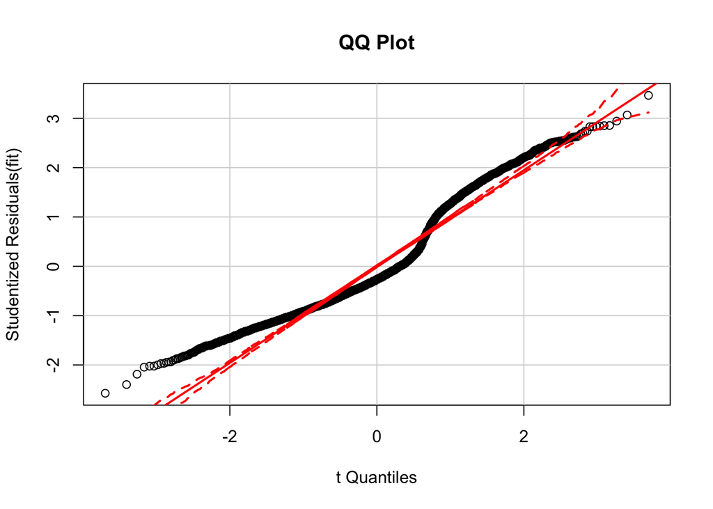

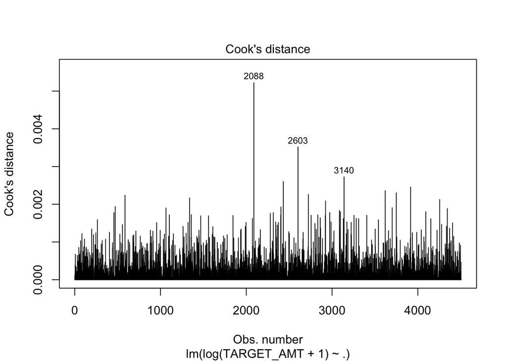

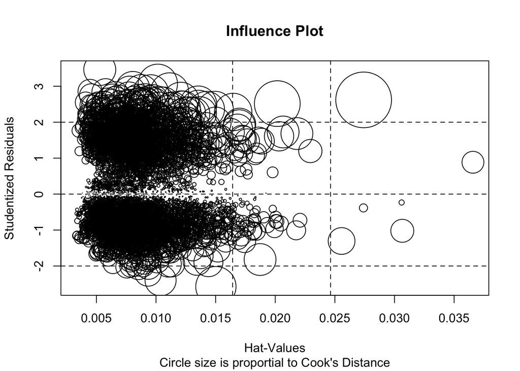

```
## Non-constant Variance Score Test
## Variance formula: ~ fitted.values
## Chisquare = 419.1293    Df = 1     p = 3.77547e-93
```

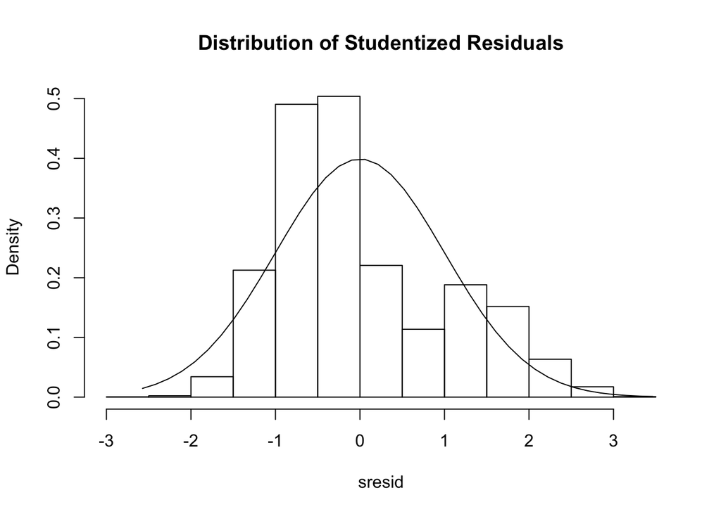

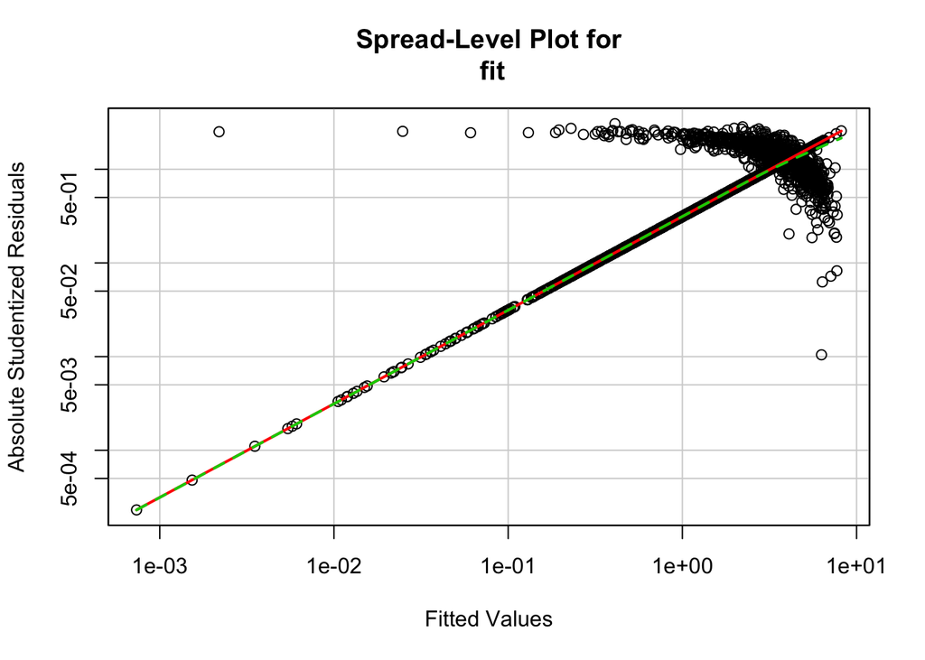

```
##  lag Autocorrelation D-W Statistic p-value
##    1     -0.02836693      2.056647   0.038
##  Alternative hypothesis: rho != 0
```

This model looks better but it is still far from perfect. The QQ Plot is greatly improved but there are still issues with cooks distance etc.

[output not shown]

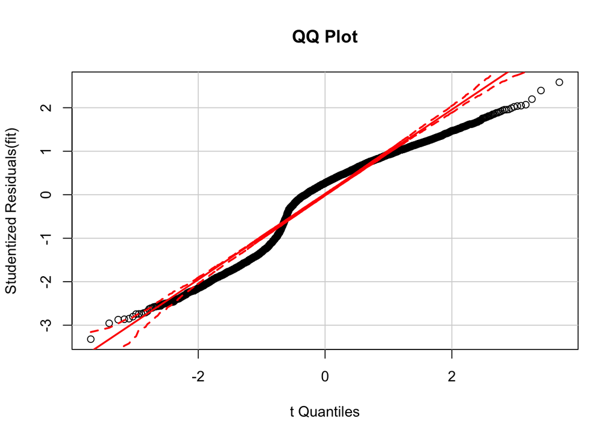

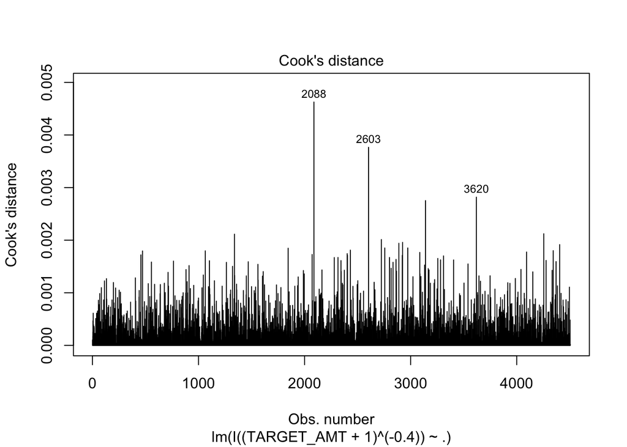

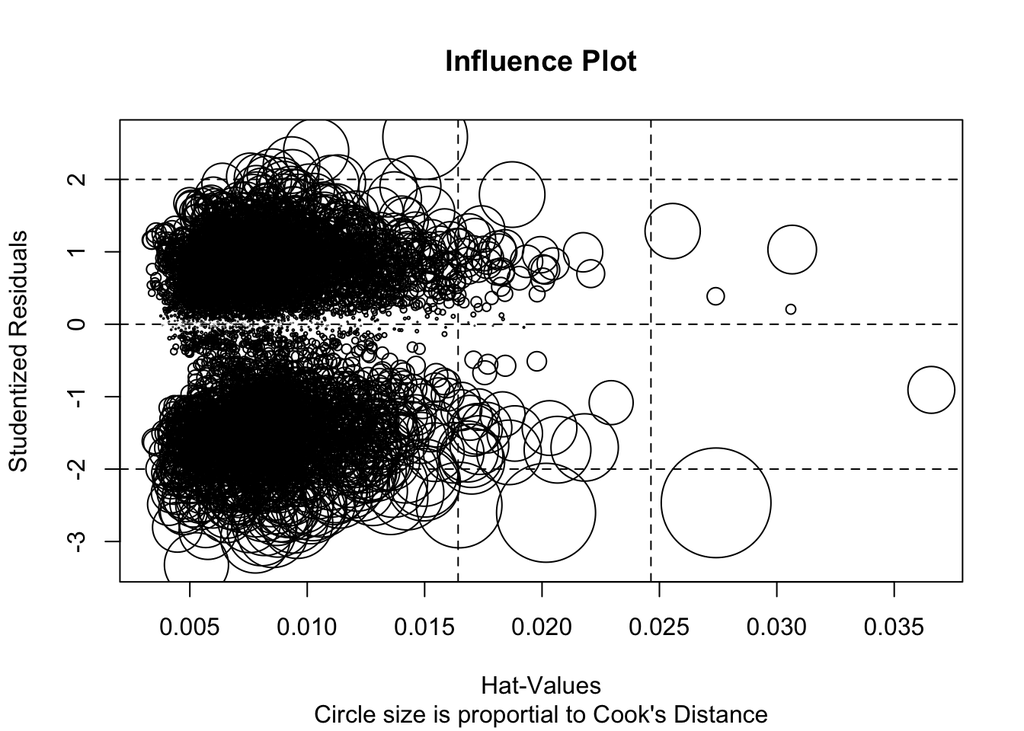

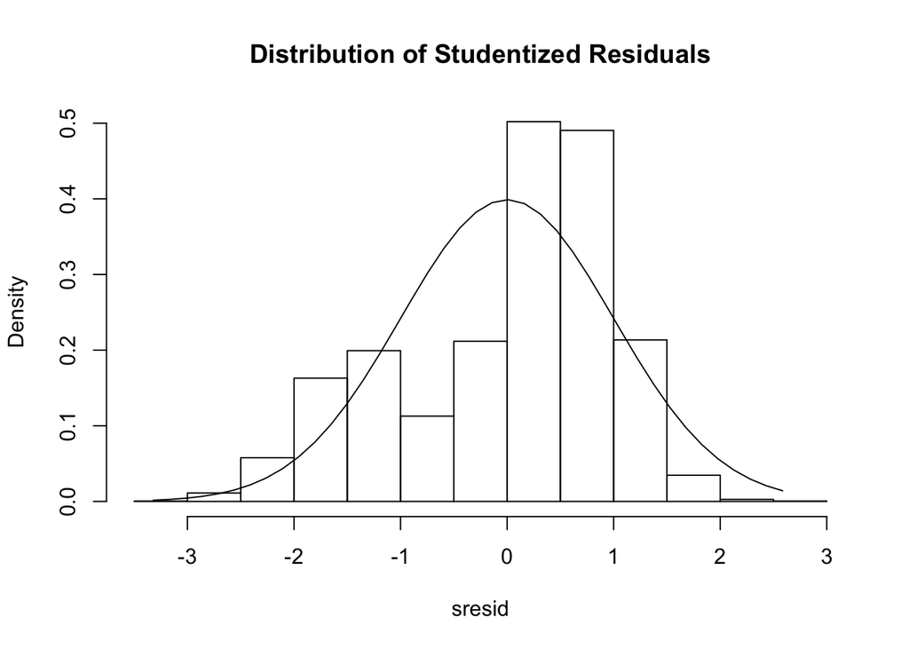

```
## Non-constant Variance Score Test
## Variance formula: ~ fitted.values
## Chisquare = 394.5613    Df = 1     p = 8.411692e-88
```

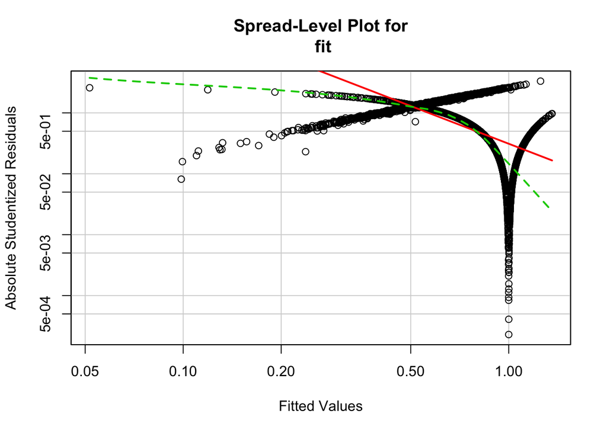

```
##  lag Autocorrelation D-W Statistic p-value
##    1     -0.03132353      2.062565   0.018
##  Alternative hypothesis: rho != 0
```

Even this model with a Box-Cox transformation has not great results. Given these results on our transformed models, I think that it might be worthwile examaning non-linear models such as tree based models. This, however, goes beyond the scope of the course.

## 4.2 Logisic Models

### 4.2.1 Basic Logistic regression

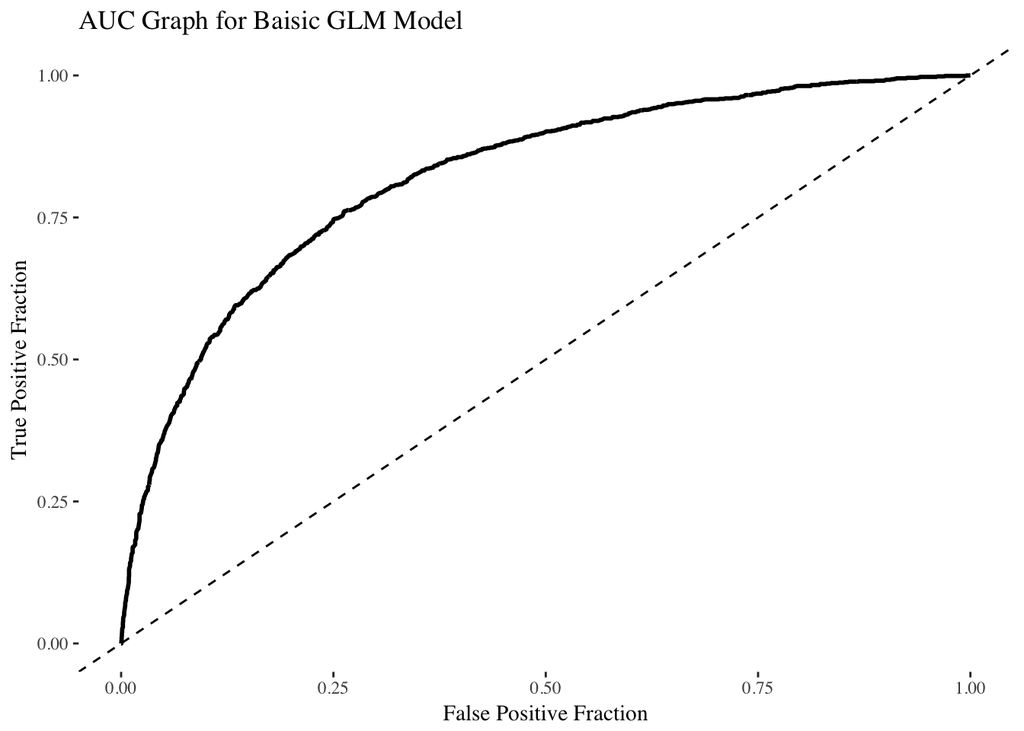

```
##
## [[2]]
## Area under the curve: 0.8207
```

### 4.2.3 LASSO Logsitic

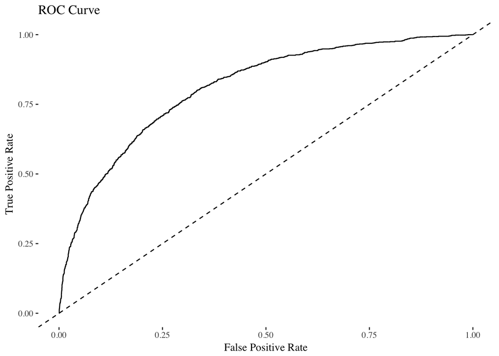

```
## [[1]]
## [1] 0.8087627
```

# 5 Model Selection

## 5.2 GLM Selection.

For the GLM Model we will use AUC as a selector. As such, I chose the baisc model.

# 6 Predictions

## 6.1 OLS

```
##          1          2          3          4          5          6
## 1.07923964 2.50448156 1.98003329 1.54566376 3.63463698 0.05468482
```

## 6.2 GLM

```
##          1          2          3          4          5          6
## 0.12471795 0.29952584 0.24145782 0.17842149 0.43940253 0.01132441
```

# 7 Apendix

```r
knitr::opts_chunk$set(echo = FALSE)
knitr::opts_knit$set(root.dir = "/Users/kailukowiak/DATA621/Assignments")
knitr::opts_chunk$set(echo=FALSE)
# Libraries
##################
library(MASS)
library(car)
library(leaps)
library(tidyverse)
library(knitr)
library(kableExtra)
library(psych)
library(ggthemes)
library(corrplot)
library(glmnet)
library(bestglm)
library(xtable)
library(caTools)
options(xtable.floating = FALSE)
options(xtable.timestamp = "")
####################
moneyCV <- function(df){
  for (colName in names(df)){
    if (grepl('\\$', df[, colName])){
      df[, colName] = gsub("\\$|,", "", df[[colName]]) %>% as.numeric()
    }
  }
  return(df)
}

factorCV <- function(df){
  for (colName in names(df)){
    if (is.character(df[[colName]])) {
      df[, colName] = df[[colName]] %>% as.factor()
    }
  }
  return(df)
}
# Loading the data

LabledDF <- read_csv('Assignment4/insurance_training_data.csv')

LabledDF <- moneyCV(LabledDF)
LabledDF <- factorCV(LabledDF)
LabledDF <- LabledDF %>% select(-INDEX)
set.seed(101)
sample = sample.split(LabledDF$TARGET_FLAG, SplitRatio = .75)
df <- subset(LabledDF, sample == TRUE)
testDF <- subset(LabledDF, sample == FALSE)
temp <- df %>% sample_n(6)
temp %>% kable()
# temp[,1:8] %>% kable(caption = 'Sample of Values for the Training Set')
# temp[9:17] %>% kable(caption = 'Sample of Values for the Training Set')
# temp[18:25] %>% kable(caption = 'Sample of Values for the Training Set')
glimpse(df)
evalDF <- read_csv('/Users/kailukowiak/DATA621/Assignments/Assignment4/insurance-evaluation-data.csv')
evalDF <- moneyCV(evalDF)
evalDF <- factorCV(evalDF)
evalDF <- evalDF %>% select(-INDEX, -TARGET_AMT, -TARGET_FLAG)
temp <- evalDF %>% sample_n(6)
temp[1:8] %>% kable(caption = 'Sample of Values for the Test Set')
###############################
setwd("~/DATA621/Assignments")
lables <- read_csv('Assignment4/dataLegend.csv')
lables %>% kable()
# Summary Tables
SumTab <- summary(df)
SumTab1 <- SumTab[, 1:6]
SumTab2 <- SumTab[, 7:13]
kable(SumTab1, caption = 'Summary Statistics')
kable(SumTab2, caption = 'Summary Statistics')
#####################
dis <- describe(df)
dis[, 1:5] %>% kable(caption = 'Descriptive Statistics')
dis[, 6:9] %>% kable(caption = 'Descriptive Statistics')
dis[, 10:13] %>% kable(caption = 'Descriptive Statistics')
temp <- map(df, ~sum(is.na(.)))
temp <- t(temp)
temp[1:8] %>% kable(caption = 'Count of NA Values')
temp[9:17] %>% kable(caption = 'Count of NA Values')
temp[18:25] %>% kable(caption = 'Count of NA Values')

df$CONTAINS_NA <- ifelse(complete.cases(df), FALSE, TRUE)

corFlag <- cor(df$TARGET_FLAG, df$CONTAINS_NA)
corAmt <- cor(df$TARGET_AMT, df$CONTAINS_NA)
df <- df %>% select(-CONTAINS_NA)
df <- df[complete.cases(df),]
evalDF <- evalDF[complete.cases(evalDF),]
testDF <- testDF[complete.cases(testDF),]
df %>%
  select_if(is.numeric) %>%
  scale() %>%
  as_tibble() %>%
  gather() %>%
  ggplot(aes(x = key, y = value)) +
  theme_tufte() +
  geom_violin()+
  #geom_tufteboxplot(outlier.colour="black")+
  theme(axis.title=element_blank()) +
  ylab('Scaled Values')+
  xlab('Variable')+
  theme(axis.text.x = element_text(angle = 90, hjust = 1))+
  ggtitle('Distrobution of Values', subtitle = 'Y values scaled to fit a common axis')
df %>%
  select_if(is.numeric) %>%
  scale() %>%
  as_tibble() %>%
  gather() %>%
  ggplot(aes(x = key, y = value)) +
  # geom_violin()+
  # geom_tufteboxplot(outlier.colour="black", outlier.shape = 22)+
  geom_boxplot()+
  theme_tufte() +
  theme(axis.title=element_blank()) +
  ylab('Scaled Values')+
  xlab('Variable')+
  theme(axis.text.x = element_text(angle = 90, hjust = 1))+
  ggtitle('Distrobution of Values', subtitle = 'Y values scaled to fit a common axis')
df %>%
  select_if(is.factor) %>%
  gather() %>%
  ggplot(aes(x=value))+
  geom_bar()+
  facet_wrap(~key,scales='free_x')+
  theme(axis.text.x = element_text(angle = 90, hjust = 1))
dfCont <- df %>% select(-TARGET_FLAG)
dfLog <- df %>% select(-TARGET_AMT)
mod1 <- lm(TARGET_AMT ~ ., data = dfCont)
#summary(mod1)
options(xtable.comment = FALSE)
summary(mod1)
mod2 <- lm(log(TARGET_AMT+1) ~ ., data = dfCont) # Note the `+1`
summary(mod2)

# Box Cox Method, univariate
summary(p1 <- powerTransform(I(TARGET_AMT+1) ~ ., dfCont))

bcTrans <- lm(I((TARGET_AMT+1)^(-0.4)) ~ ., dfCont)
summary(bcTrans)
logMod1 <- glm(TARGET_FLAG~., data = dfLog)
logMod1 %>% summary()
X <- dfLog %>% dplyr::select(-TARGET_FLAG)
X <- data.matrix(X)
#X <- as.matrix(X, ncol=12)
y <- as.factor(dfLog$TARGET_FLAG)
fit = glmnet(X, y, family = "binomial")
library(ROCR)
aucDF <- X
lasso.model = cv.glmnet(X, y, family = "binomial", type.measure = 'class')

aucDF$lasso.prob <- predict(lasso.model, type="response", newx = X, s = 'lambda.1se')
pred <- prediction(aucDF$lasso.prob, y)


cvfit = cv.glmnet(X, y, family = "binomial", type.measure = "class")
plot(cvfit)
coef(cvfit, s = "lambda.1se")
# theoDF <- dfLog %>% select(TARGET_FLAG, KIDSDRIV, AGE, OLDCLAIM, REVOKED, RED_CAR,)
# modTheo <- glm(TARGET_FLAG~., data = theoDF)
# summary(modTheo) %>% xtable()
regressionDiagnostic <- function(fit){
  ## https://www.statmethods.net/stats/rdiagnostics.html
  library(car) # Required
  print(outlierTest(fit))
  qqPlot(fit, main = 'QQ Plot')
  #av.Plots(fit)
  cutoff <- 4/((nrow(dfCont)-length(fit$coefficients)-2))
  plot(fit, which=4, cook.levels=cutoff)
  # Influence Plot
  influencePlot(fit,    id.method="identify", main="Influence Plot",
                sub="Circle size is proportial to Cook's Distance" )
  library(MASS)
  sresid <- studres(fit)
  hist(sresid, freq=FALSE,
       main="Distribution of Studentized Residuals")
  xfit<-seq(min(sresid),max(sresid),length=40)
  yfit<-dnorm(xfit)
  lines(xfit, yfit)
  print(ncvTest(fit))
  # plot studentized residuals vs. fitted values
  spreadLevelPlot(fit)
  print(durbinWatsonTest(fit))
}
regressionDiagnostic(mod1)
regressionDiagnostic(mod2)
regressionDiagnostic(bcTrans)
AUC <- function(df, mod, modelName){
  library(plotROC)
  library(pROC)
  prob = predict(mod,type = c("response"))
  dfLog$prob=prob
  p = ggplot(dfLog, aes(d = TARGET_FLAG, m = prob)) +
    geom_roc(n.cuts = 0) +
    ggtitle(paste('AUC Graph for', modelName)) +
    xlab("False Positive Fraction") +
    ylab('True Positive Fraction') +
    geom_abline(linetype = 'dashed') +
    theme_tufte()

  g <- roc(TARGET_FLAG ~ prob, data = dfLog)
  return(list(p, g$auc))
}
AUC(select(testDF, -TARGET_AMT), logMod1, 'Baisic GLM Model')

#AUC(select(testDF, -TARGET_AMT), modTheo, 'Theoretical Model')
#testX <- a
fittedGLMcv <- predict(cvfit, X, s = "lambda.1se", type = "class")

perf <- performance(pred,"tpr","fpr")
auc <-  performance(pred,"auc") # shows calculated AUC for model
auc <- auc@y.values

roc.data <- data.frame(fpr=unlist(perf@x.values),
                       tpr=unlist(perf@y.values))

ggplot(roc.data, aes(x=fpr, ymin=0, ymax=tpr)) +
    #geom_ribbon(alpha=0.2) +
    geom_line(aes(y=tpr)) +
    geom_abline(slope=1, intercept=0, linetype='dashed') +
    ggtitle("ROC Curve") +
    ylab('True Positive Rate') +
    xlab('False Positive Rate') + theme_tufte()
auc
#evalDF <- evalDF %>% select(-CONTAINS_NA)
predict(mod2,newdata = evalDF) %>% head()
predict(logMod1, newdata = evalDF) %>% head()
```